# FMBN stats: a script for extracting summary statistics from FoodMicrobionet

Prof. E. Parente, Scuola SAFE, Università degli Studi della Basilicata

02 August 2022

# FMBN statistics.

# Statistics on studies.

This is version 4.2 of FoodMicrobionet. Last updated 13/07/2022. this version includes extra fields and tables. The number of studies in FMBN is 211.

| FMBN_version | nstudies | nsamples | cum_sum_studies | cum_sum_samples |
| --- | --- | --- | --- | --- |
| 0_6_2 | 4 | 127 | 4 | 127 |
| 1_0_3 | 2 | 68 | 6 | 195 |
| 1_1 | 4 | 181 | 10 | 376 |
| 2 | 4 | 192 | 14 | 568 |
| 3_1 | 11 | 511 | 25 | 1079 |
| 3_2 | 126 | 7490 | 151 | 8569 |
| 4_1 | 10 | 428 | 161 | 8997 |
| 4_2 | 50 | 3748 | 211 | 12745 |

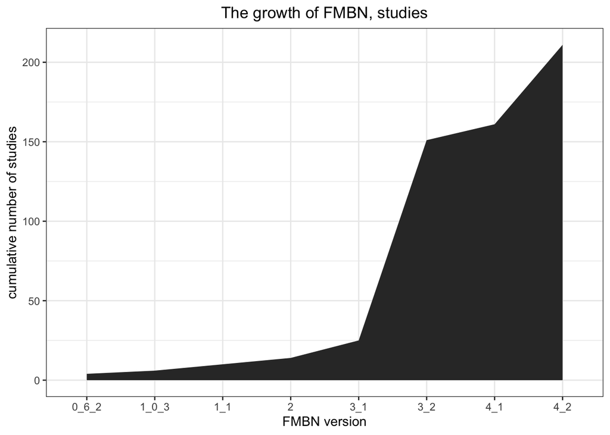

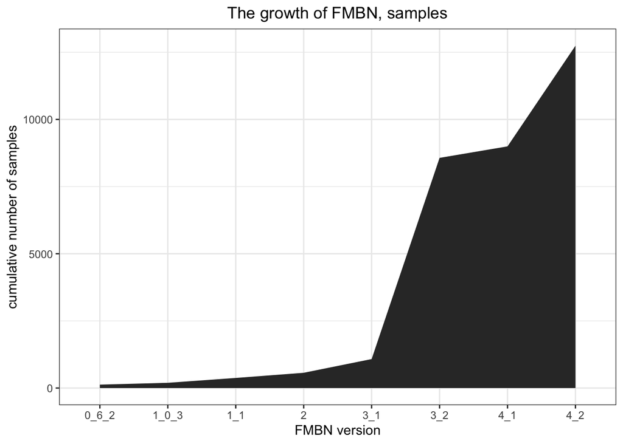

The largest growth in studies and samples has been between version 3.1 (published in 2019) and version 3.2 (unpublished).

## Platforms, gene target, regions.

FMBN grows by addition of sequences deposited in NCBI SRA for published studies. As a consequence, use of targets (16S RNA, 16S RNA gene) reflect what is published and the correlation between platforms and targets.

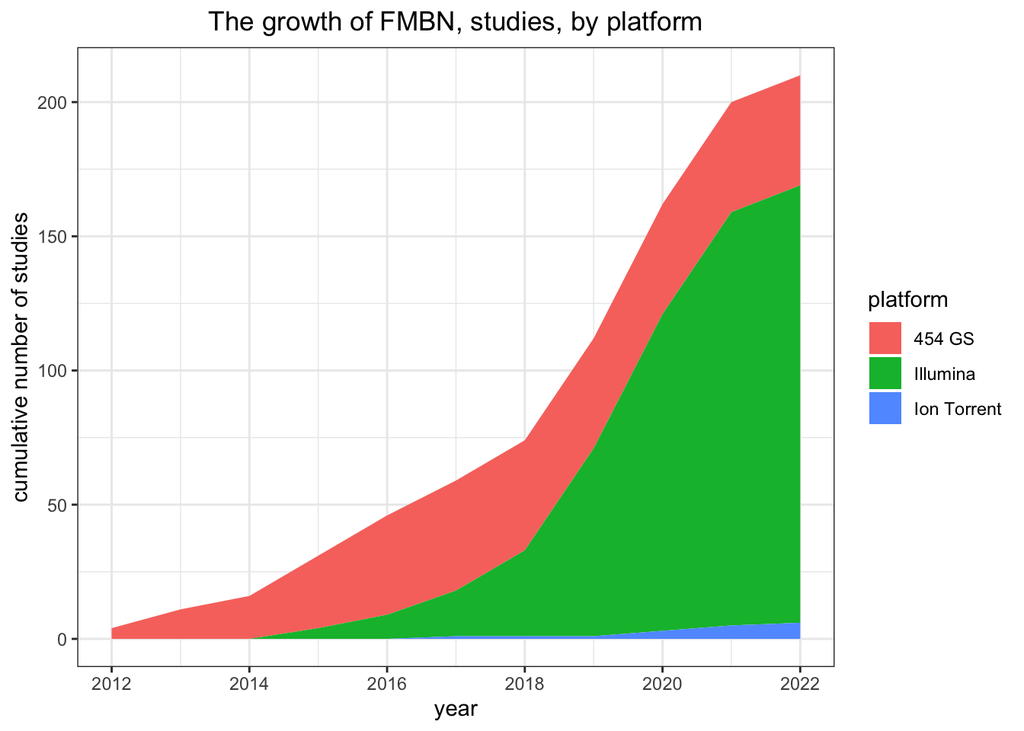

| platform_2 | n | prop |
| --- | --- | --- |
| 454 GS | 42 | 0.19905213 |
| Illumina | 163 | 0.77251185 |
| Ion Torrent | 6 | 0.02843602 |

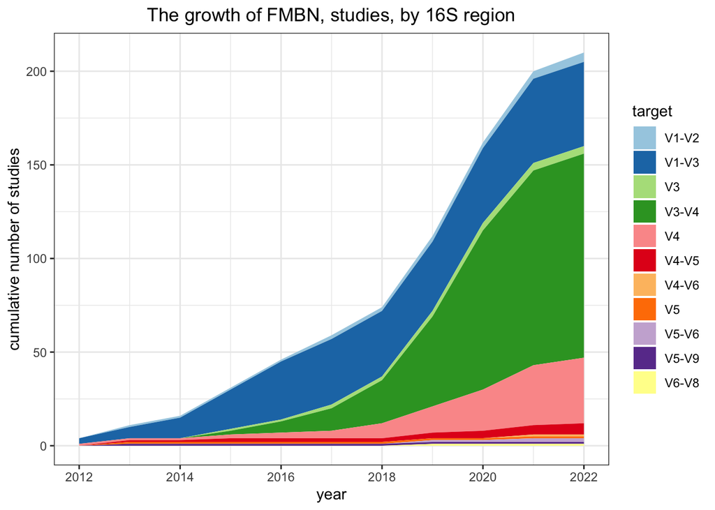

```
##        platform_2
## region  454 GS Illumina Ion Torrent Sum
##   V1-V2      1        2           2   5
##   V1-V3     33       13           0  46
##   V3         1        3           0   4
##   V3-V4      1      108           0 109
##   V4         2       30           3  35
##   V4-V5      2        4           0   6
##   V4-V6      0        1           0   1
##   V5         1        0           0   1
##   V5-V6      0        1           1   2
##   V5-V9      1        0           0   1
##   V6-V8      0        1           0   1
##   Sum       42      163           6 211
```

| food_group | n | prop | cum_prop |
| --- | --- | --- | --- |
| Dairy | 87 | 0.412322275 | 0.4123223 |
| Meat | 45 | 0.213270142 | 0.6255924 |
| Vegetables | 40 | 0.189573460 | 0.8151659 |
| Fish and seafood | 13 | 0.061611374 | 0.8767773 |
| Miscellaneous | 9 | 0.042654028 | 0.9194313 |
| Doughs | 8 | 0.037914692 | 0.9573460 |
| Alcoholic beverages | 7 | 0.033175355 | 0.9905213 |
| Eggs and egg products | 2 | 0.009478673 | 1.0000000 |

FMBN includes studies on 8 food groups. The majority of studies is on dairy products.

# Statistics on samples.

The number of samples in FMBN has been rising almost exponentially with time. FMBN is the richest database in terms of number of samples for foods and food environments, and it is also the best annotated one.

## Statistics by food group.

| L1 | n | prop | cumprop |
| --- | --- | --- | --- |
| Milk and dairy products | 5642 | 0.4426 | 0.4426 |
| Meat and meat products | 3533 | 0.2771 | 0.7197 |
| Vegetables and vegetable products | 1164 | 0.0913 | 0.8110 |
| Fish, seafood, amphibians, reptiles and invertebrates | 622 | 0.0488 | 0.8598 |
| Fruit and fruit products | 545 | 0.0428 | 0.9026 |
| Major isolated ingredients, additives, flavours, baking and processing aids | 287 | 0.0225 | 0.9251 |
| Seasoning, sauces and condiments | 198 | 0.0155 | 0.9406 |
| Alcoholic beverages | 172 | 0.0135 | 0.9541 |
| Composite dishes | 147 | 0.0115 | 0.9656 |
| Grains and grain-based products | 96 | 0.0075 | 0.9732 |
| Legumes, nuts, oilseeds and spices | 81 | 0.0064 | 0.9795 |
| Fruit and vegetable juices and nectars (including concentrates) | 69 | 0.0054 | 0.9849 |
| Eggs and egg products | 56 | 0.0044 | 0.9893 |
| Animal and vegetable fats and oils and primary derivatives thereof | 53 | 0.0042 | 0.9935 |
| Sugar and similar, confectionery and water-based sweet desserts | 42 | 0.0033 | 0.9968 |
| Starchy roots or tubers and products thereof, sugar plants | 17 | 0.0013 | 0.9981 |
| Coffee, cocoa, tea and infusions | 12 | 0.0009 | 0.9991 |
| Water and water-based beverages | 12 | 0.0009 | 1.0000 |

## Statistics by gene targets and number of sequences.

The structure of FoodMicrobionet allows the user to fine-tune each search and extract just the combination of samples s/he desires. Below, I am showing a few stats on number of sequences, by region. However, the user can perform searches based on the type of target, the region, he length of sequences per sample and even the occurrence of issues during the bioinformatic analysis (low number of sequences, high proportion of losses in a specific phase of the pipeline).

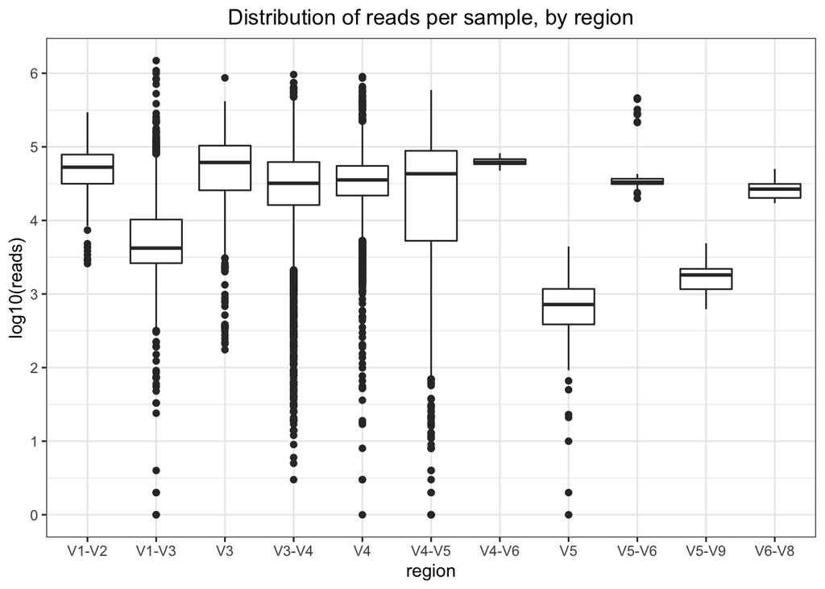

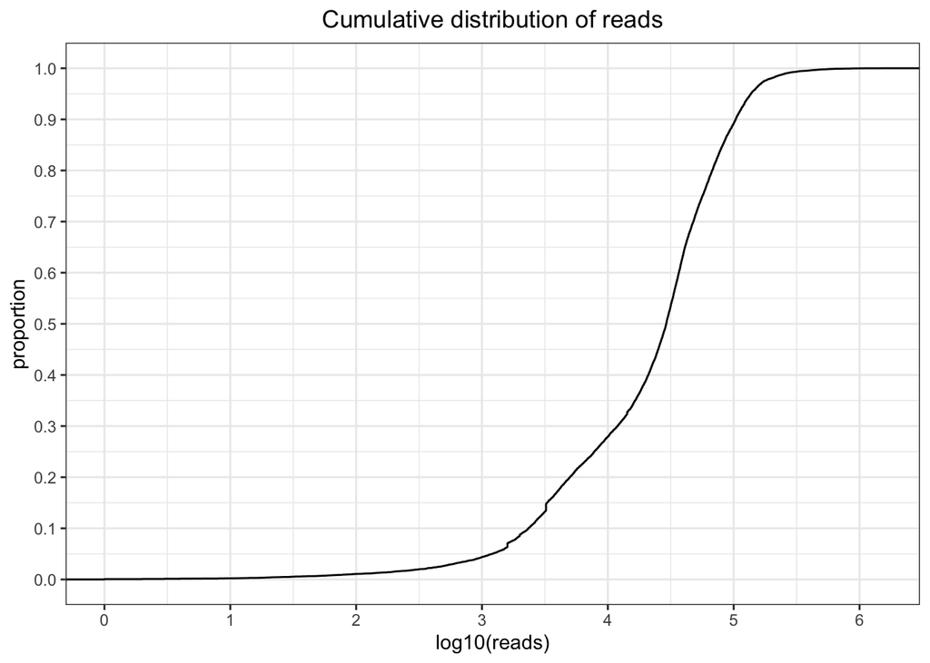

## Geographical distribution of samples.

From version 4.1.2 geographic location of samples (when provided in metadata) was added to the samples table.  
We plan to fill up this information on existing ssamples and will continue adding it to new samples. However, interested users should always double check on the original paper for the meaning of the coordinates (are they the place of sampling? the origin of the food? For example, there is a Japanese study studying imported French cheeses: which should be the location?).

| geo_loc_continent | n | prop | cumprop |
| --- | --- | --- | --- |
| Europe | 7006 | 0.5496 | 0.5496 |
| North America | 2143 | 0.1681 | 0.7177 |
| Asia | 1903 | 0.1493 | 0.8670 |
| Oceania | 901 | 0.0707 | 0.9376 |
| Africa | 375 | 0.0294 | 0.9671 |
| South America | 316 | 0.0248 | 0.9918 |
| Belgium | 104 | 0.0082 | 1.0000 |

| geo_loc_country | n | prop | cumprop |
| --- | --- | --- | --- |
| Italy | 2958 | 0.2320 | 0.2320 |
| United States of America | 1600 | 0.1255 | 0.3575 |
| France | 944 | 0.0741 | 0.4316 |
| Norway | 941 | 0.0738 | 0.5054 |
| Australia | 893 | 0.0701 | 0.5755 |
| China | 778 | 0.0610 | 0.6365 |
| Ireland | 522 | 0.0409 | 0.6774 |
| South Korea | 487 | 0.0382 | 0.7156 |
| Canada | 423 | 0.0332 | 0.7488 |
| United Kingdom | 371 | 0.0291 | 0.7779 |
| Belgium | 285 | 0.0224 | 0.8003 |
| Sweden | 241 | 0.0189 | 0.8192 |
| Cyprus | 223 | 0.0175 | 0.8367 |
| Brazil | 217 | 0.0170 | 0.8537 |
| Senegal | 120 | 0.0094 | 0.8631 |
| Europe | 104 | 0.0082 | 0.8713 |
| Japan | 101 | 0.0079 | 0.8792 |
| Finland | 96 | 0.0075 | 0.8867 |
| Austria | 91 | 0.0071 | 0.8939 |
| Spain | 88 | 0.0069 | 0.9008 |
| Thailand | 84 | 0.0066 | 0.9074 |
| Greenland | 75 | 0.0059 | 0.9132 |
| Benin | 66 | 0.0052 | 0.9184 |
| Netherlands | 63 | 0.0049 | 0.9234 |
| Malaysia | 61 | 0.0048 | 0.9281 |
| Cameroon | 58 | 0.0045 | 0.9327 |
| Germany | 58 | 0.0045 | 0.9372 |
| Israel | 56 | 0.0044 | 0.9416 |
| Denmark | 46 | 0.0036 | 0.9452 |
| Mexico | 45 | 0.0035 | 0.9488 |
| Colombia | 40 | 0.0031 | 0.9519 |
| Laos | 40 | 0.0031 | 0.9551 |
| South Africa | 36 | 0.0028 | 0.9579 |
| Switzerland | 36 | 0.0028 | 0.9607 |
| NA | 33 | 0.0026 | 0.9633 |
| Estonia | 32 | 0.0025 | 0.9658 |
| Pakistan | 31 | 0.0024 | 0.9682 |
| Greece | 29 | 0.0023 | 0.9705 |
| Croatia | 28 | 0.0022 | 0.9727 |
| Portugal | 27 | 0.0021 | 0.9748 |
| Brasil | 26 | 0.0020 | 0.9769 |
| Hungary | 23 | 0.0018 | 0.9787 |
| Iceland | 20 | 0.0016 | 0.9802 |
| Russia | 20 | 0.0016 | 0.9818 |
| Argentina | 17 | 0.0013 | 0.9831 |
| Bosnia-Erzegovina | 15 | 0.0012 | 0.9843 |
| Iran | 15 | 0.0012 | 0.9855 |
| Madagascar | 14 | 0.0011 | 0.9866 |
| Kazakhstan | 13 | 0.0010 | 0.9876 |
| Poland | 13 | 0.0010 | 0.9886 |
| Zambia | 13 | 0.0010 | 0.9896 |
| Gabon | 12 | 0.0009 | 0.9906 |
| Serbia | 11 | 0.0009 | 0.9914 |
| Ghana | 10 | 0.0008 | 0.9922 |
| Guyana | 10 | 0.0008 | 0.9930 |
| Maldives | 10 | 0.0008 | 0.9938 |
| Nigeria | 8 | 0.0006 | 0.9944 |
| Papua New Guinea | 8 | 0.0006 | 0.9951 |
| Chile | 6 | 0.0005 | 0.9955 |
| Guinea | 6 | 0.0005 | 0.9960 |
| Morocco | 6 | 0.0005 | 0.9965 |
| Great Britain | 5 | 0.0004 | 0.9969 |
| Zimbabwe | 5 | 0.0004 | 0.9973 |
| Rwanda | 4 | 0.0003 | 0.9976 |
| Svalbard | 4 | 0.0003 | 0.9979 |
| Uganda | 4 | 0.0003 | 0.9982 |
| Burkina Faso | 3 | 0.0002 | 0.9984 |
| Ethiopia | 3 | 0.0002 | 0.9987 |
| Tanzania | 3 | 0.0002 | 0.9989 |
| Czech Republic | 2 | 0.0002 | 0.9991 |
| Indonesia | 2 | 0.0002 | 0.9992 |
| Kenya | 2 | 0.0002 | 0.9994 |
| Lithuania | 2 | 0.0002 | 0.9995 |
| Namibia | 2 | 0.0002 | 0.9997 |
| Viet Nam | 2 | 0.0002 | 0.9998 |
| Latvia | 1 | 0.0001 | 0.9999 |
| NA | 1 | 0.0001 | 1.0000 |

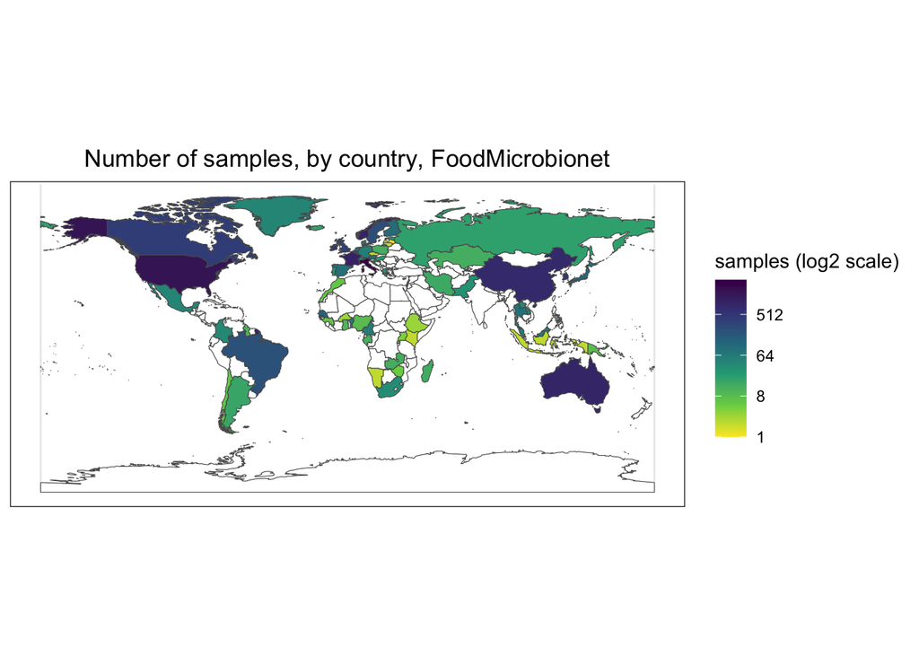

# Statistics for taxa.

For all studies belonging to version 1.1 or higher, FoodMicrobionet was created by a dedicated pipeline using SILVA for taxonomic assignment. The revision of samples belonging to previous version is in progress and, in the future, a script will be used to reprocess sequences when a new version of SILVA is releases. A few tweaks on taxonomy are needed for coherence and for compatibility with external databases.  
We always try to assign sequences to the lowest possible level (given the length of sequences and their quality). Statistics for taxonomic assignment are shown below.

| idelevel | n | prop | cumprop |
| --- | --- | --- | --- |
| species | 4912 | 0.5095 | 0.5095 |
| genus | 3368 | 0.3494 | 0.8589 |
| family | 660 | 0.0685 | 0.9274 |
| order | 375 | 0.0389 | 0.9663 |
| class | 240 | 0.0249 | 0.9912 |
| phylum | 81 | 0.0084 | 0.9996 |
| domain | 4 | 0.0004 | 1.0000 |

| phylum | n | prop | cumprop | cumn | roworder | cumroworder |
| --- | --- | --- | --- | --- | --- | --- |
| Proteobacteria | 3096 | 0.3212 | 0.3212 | 3096 | 1 | 1 |
| Firmicutes | 2046 | 0.2122 | 0.5334 | 5142 | 2 | 3 |
| Actinobacteriota | 1354 | 0.1405 | 0.6739 | 6496 | 3 | 6 |
| Bacteroidota | 1234 | 0.1280 | 0.8019 | 7730 | 4 | 10 |
| Cyanobacteria | 243 | 0.0252 | 0.8271 | 7973 | 5 | 15 |
| Verrucomicrobiota | 143 | 0.0148 | 0.8419 | 8116 | 6 | 21 |
| Desulfobacterota | 135 | 0.0140 | 0.8559 | 8251 | 7 | 28 |
| Acidobacteriota | 133 | 0.0138 | 0.8697 | 8384 | 8 | 36 |
| Chloroflexi | 119 | 0.0123 | 0.8821 | 8503 | 9 | 45 |
| Planctomycetota | 115 | 0.0119 | 0.8940 | 8618 | 10 | 55 |
| Patescibacteria | 107 | 0.0111 | 0.9051 | 8725 | 11 | 66 |
| Campylobacterota | 74 | 0.0077 | 0.9128 | 8799 | 12 | 78 |
| Myxococcota | 73 | 0.0076 | 0.9203 | 8872 | 13 | 91 |
| Halobacterota | 58 | 0.0060 | 0.9263 | 8930 | 14 | 105 |
| Spirochaetota | 55 | 0.0057 | 0.9321 | 8985 | 15 | 120 |
| Deinococcota | 54 | 0.0056 | 0.9377 | 9039 | 16 | 136 |
| Fusobacteriota | 35 | 0.0036 | 0.9413 | 9074 | 17 | 153 |
| Ascomycota | 34 | 0.0035 | 0.9448 | 9108 | 18 | 171 |
| Synergistota | 34 | 0.0035 | 0.9483 | 9142 | 19 | 190 |
| Bdellovibrionota | 23 | 0.0024 | 0.9507 | 9165 | 20 | 210 |
| Basidiomycota | 21 | 0.0022 | 0.9529 | 9186 | 21 | 231 |
| Crenarchaeota | 20 | 0.0021 | 0.9550 | 9206 | 22 | 253 |
| Fibrobacterota | 19 | 0.0020 | 0.9570 | 9225 | 23 | 276 |
| Ciliophora | 18 | 0.0019 | 0.9588 | 9243 | 24 | 300 |
| Chlorophyta_ph | 17 | 0.0018 | 0.9606 | 9260 | 25 | 325 |
| Gemmatimonadota | 17 | 0.0018 | 0.9623 | 9277 | 26 | 351 |
| Phragmoplastophyta | 17 | 0.0018 | 0.9641 | 9294 | 27 | 378 |
| Elusimicrobiota | 16 | 0.0017 | 0.9658 | 9310 | 28 | 406 |
| Ochrophyta | 15 | 0.0016 | 0.9673 | 9325 | 29 | 435 |
| Armatimonadota | 14 | 0.0015 | 0.9688 | 9339 | 30 | 465 |

[output cut: 125 more lines]

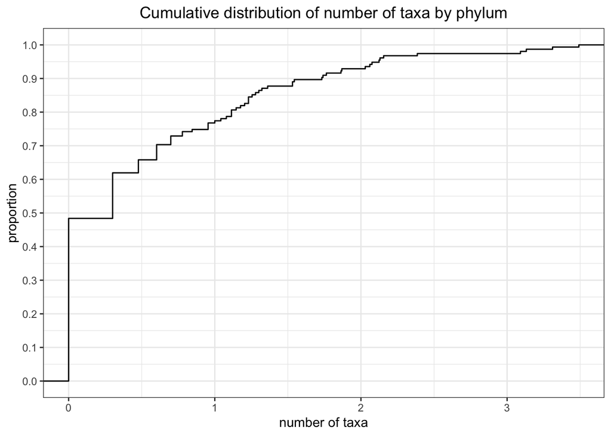

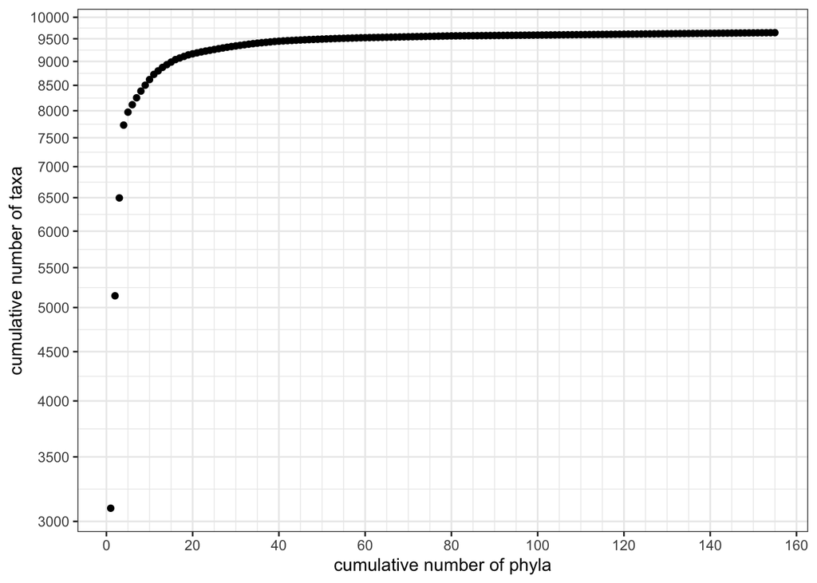

## More on taxonomic assignment.

The depth of taxonomic assignment depends on a number of factors (quality and length of the sequences, quality of the reference database, etc.). Here, we will present tables and graphs on this subject.

After some processing to obtain the information from the various tables, here is a box plot showing identifications at the genus level or below, by region.

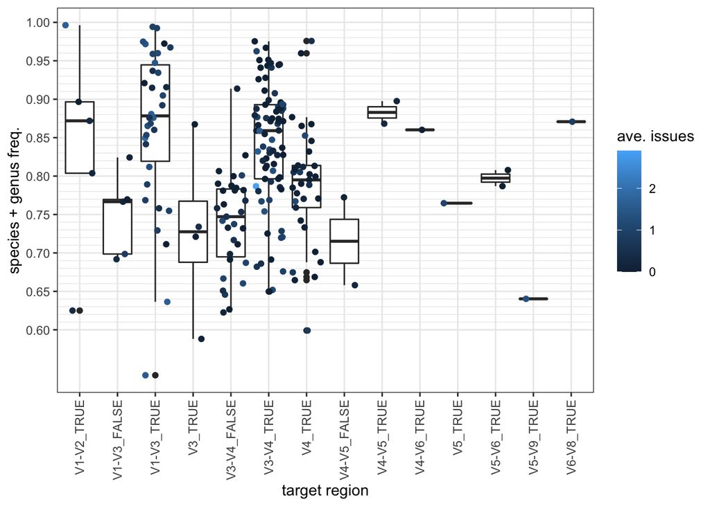

Longer sequences for which a good overlap was obtained in paired end sequences (_TRUE) clearly result in a higher proportion of taxonomic assignments at the genus level or below. There is some relationship with the quality of sequences /number of issues encountered during bioinformatic processing: with more issues, in general, the quality of taxonomic assignment is worse, but this is not always true.  
However, if one keeps into account the number of sequences rather than just counting the ASVs for which assignment at the genus level or below level was possible, it is clear that a high proportion of total sequences received taxonomic assignment at the genus level or below.

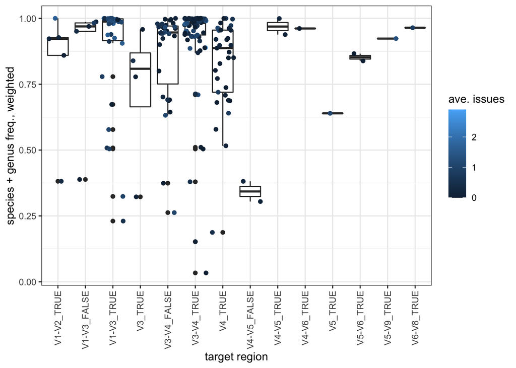

It is very likely that this situation may depend on biases in the composition of reference taxonomic databases (in this case SILVA v138.1), in which the number of sequences varies widely in different taxonomic groups.

The ability to obtain a taxonomic assignment down to the genus level varies by phylum. Only the 4 most abundant phyla are shown.

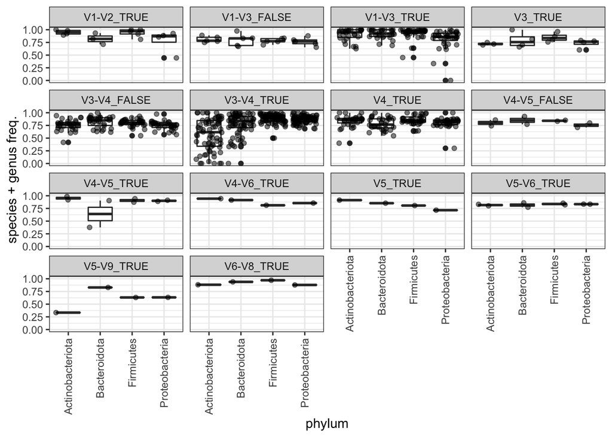

This is even more evident if the data are weighted using the number of sequences and if only the most common target regions are used.

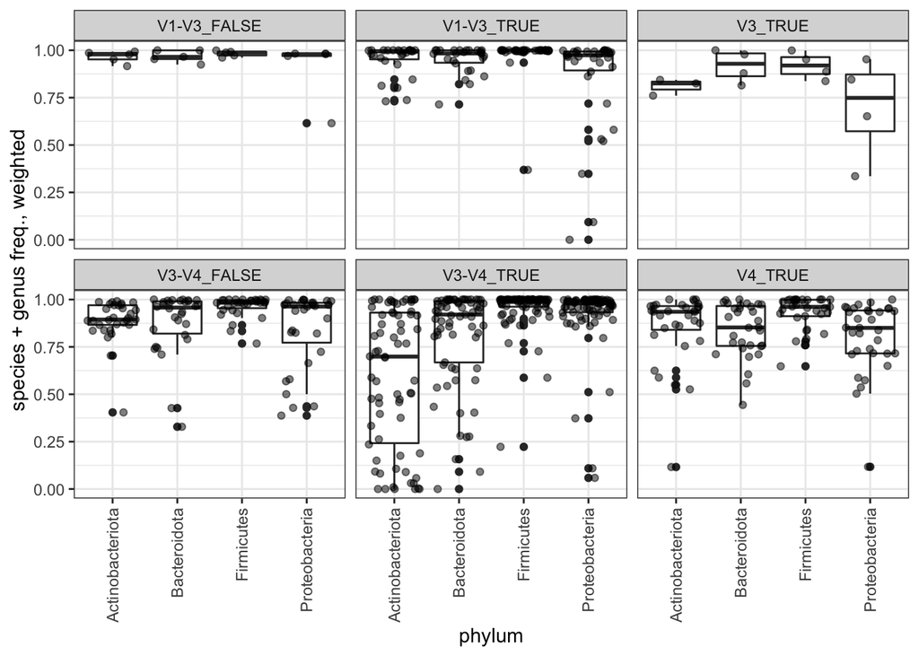

Taxonomic assignment down to the genus level is clearly worse for Actinobacterota and Bacteroidota and region V1-V3 tipycally results in a higher proportion of taxonomic assignments down to the genus level. However, this is likely to be confounded with the taxonomic platform.

# Credits and copyright.

This is version 2.1 of the script, 2/8/2022.

Assume that the code in this document is overall under MIT licence

Copyright 2021, 2022 Eugenio Parente, Università degli Studi della Basilicata. Permission is hereby granted, free of charge, to any person obtaining a copy of this software and associated documentation files (the “Software”), to deal in the Software without restriction, including without limitation the rights to use, copy, modify, merge, publish, distribute, sublicense, and/or sell copies of the Software, and to permit persons to whom the Software is furnished to do so, subject to the following conditions: THE SOFTWARE IS PROVIDED “AS IS”, WITHOUT WARRANTY OF ANY KIND, EXPRESS OR IMPLIED, INCLUDING BUT NOT LIMITED TO THE WARRANTIES OF MERCHANTABILITY, FITNESS FOR A PARTICULAR PURPOSE AND NONINFRINGEMENT. IN NO EVENT SHALL THE AUTHORS OR COPYRIGHT HOLDERS BE LIABLE FOR ANY CLAIM, DAMAGES OR OTHER LIABILITY, WHETHER IN AN ACTION OF CONTRACT, TORT OR OTHERWISE, ARISING FROM, OUT OF OR IN CONNECTION WITH THE SOFTWARE OR THE USE OR OTHER DEALINGS IN THE SOFTWARE.

## Citations for R packages used in this document.

```
## $tidyverse
##
##
##   Wickham H, Averick M, Bryan J, Chang W, McGowan LD, François R,
##   Grolemund G, Hayes A, Henry L, Hester J, Kuhn M, Pedersen TL, Miller
##   E, Bache SM, Müller K, Ooms J, Robinson D, Seidel DP, Spinu V,
##   Takahashi K, Vaughan D, Wilke C, Woo K, Yutani H (2019). "Welcome to
##   the tidyverse." _Journal of Open Source Software_, *4*(43), 1686.
##   doi:10.21105/joss.01686 <https://doi.org/10.21105/joss.01686>.
##
## A BibTeX entry for LaTeX users is
##
##   @Article{,
##     title = {Welcome to the {tidyverse}},
##     author = {Hadley Wickham and Mara Averick and Jennifer Bryan and Winston Chang and Lucy D'Agostino McGowan and Romain François and Garrett Grolemund and Alex Hayes and Lionel Henry and Jim Hester and Max Kuhn and Thomas Lin Pedersen and Evan Miller and Stephan Milton Bache and Kirill Müller a…
##     year = {2019},
##     journal = {Journal of Open Source Software},
##     volume = {4},
##     number = {43},
##     pages = {1686},
##     doi = {10.21105/joss.01686},
##   }
##
##
## $randomcoloR
##
##
##   Ammar R (2019). _randomcoloR: Generate Attractive Random Colors_. R
##   package version 1.1.0.1,
##   <https://CRAN.R-project.org/package=randomcoloR>.
##
## A BibTeX entry for LaTeX users is
##
##   @Manual{,
##     title = {randomcoloR: Generate Attractive Random Colors},
##     author = {Ron Ammar},
##     year = {2019},
##     note = {R package version 1.1.0.1},
##     url = {https://CRAN.R-project.org/package=randomcoloR},
##   }
```

[output cut: 48 more lines]

```
##
##
##   South A (2017). _rnaturalearthdata: World Vector Map Data from
##   Natural Earth Used in 'rnaturalearth'_. R package version 0.1.0,
##   <https://CRAN.R-project.org/package=rnaturalearthdata>.
##
## A BibTeX entry for LaTeX users is
##
##   @Manual{,
##     title = {rnaturalearthdata: World Vector Map Data from Natural Earth Used in 'rnaturalearth'},
##     author = {Andy South},
##     year = {2017},
##     note = {R package version 0.1.0},
##     url = {https://CRAN.R-project.org/package=rnaturalearthdata},
##   }
```

## Citations for FoodMicrobionet.

| Reference | DOI |
| --- | --- |
| Parente, E., Cocolin, L., De Filippis, F., Zotta, T., Ferrocino, I., O’Sullivan, O., Neviani, E., De Angelis, M., Cotter, P. D., Ercolini, D. 2016. FoodMicrobionet: a database for the visualisation an… | 10.1016/j.ijfoodmicro.2015.12.001 |
| De Filippis, F., Parente, E., Zotta, T., Ercolini, D. 2018.A comparison of bioinformatic approaches for 16S rRNA gene profiling of food bacterial microbiota. Int. J. Food Microbiol. 265:9-17. | 10.1016/j.ijfoodmicro.2017.10.028 |
| Parente, E., De Filippis, F., Ercolini, D., Ricciardi, A., Zotta, T., 2019. Advancing integration of data on food microbiome studies: FoodMicrobionet 3.1, a major upgrade of the FoodMicrobionet databa… | 10.1016/j.ijfoodmicro.2019.108249 |
| Parente, E., Zotta, T., Ricciardi, A., 2022. FoodMicrobionet v4: A large, integrated, open and transparent database for food bacterial communities. Int J Food Microbiol 372, 109696. | 10.1016/j.ijfoodmicro.2022.109696 |